# Exome Sample Filtering: Remove Contaminated and Low Coverage Samples (f1)

Harrison Ostridge

08/03/2021

**f1_exome.sample.filtering.Rmd - Remove Contaminated and Low Coverage Samples.** - PC1 threshold. - <1% human contamination. - >0.5x coverage.

f2_exome.sample.filtering.Rmd - Remove Related Samples. - Remove first order relatives as estimated using ngsRelate.

f3_exome.sample.filtering.Rmd - Remove Samples Which Do Not Cluster Correctly in Demographic Analyses. - Analyse PCAngsd and NGSadmix results. - Identify poor quality samples and sample swaps.

f4_exome.sample.filtering.Rmd - Reassign Swapped Samples - Identify samples which have been misslabeled and reassign them to their correct communities

f5_exome.sample.filtering.Rmd - Remove Related Swapped Samples - After reassigning swapped samples, we need to check they are not related to samples in their new (correct) communities. - This is needed because the first stage of removing relatives was ran within each of the original communities.

#### Setup

```r
rm(list=ls())
knitr::opts_knit$set(root.dir = '~/OneDrive - University College London/Projects/Ostridge_PanAf/sample_filtering/exome')
```

#### Library

```r
library(dplyr)
library(data.table)
library(ggplot2)
library(readxl)
library(plyr)
library(tidyr)
library(stringr)
library(igraph)
library(RColorBrewer)
library(ggvenn)
library(grid)
library(gridExtra)

meta_data_dir="../meta.data/"
output_dir="output/"
pcangsd_output_dir="../../pcangsd/exome/output/"
```

#### Read in data

Claudia sent me this metadata file on 08/03/2021. I have saved it as read only to prevent accidental changes (exterbal to R scripts).

The data is always ordered according to sample name. It is very important to maintain the correct order in order to match ANGSD outputs with samples. I always make sure it is in the correct order before writing any outputs. Note that the ordering can be different between R and bash, I always stick to the R ordering.

```r
# Exomes
exome=read_excel(paste0(meta_data_dir, "/Metadata_exome_PanAf.xlsx"))
## Order by sample
exome=exome[order(exome$Sample),]
## Add BAM file column (for making BAMfile lists to run ANGSD)
exome$BAM.mapped.on.target=paste0('/home/ucfajos/Scratch/data/phase1and2_exomes/BAM.mapped.on.target/', exome$Sample, '_exome.addRG.bam')

# chr21 (for comparison), sent by Claudia on 04/11/2021
chr21=read_excel(paste0(meta_data_dir, "TableS1_forAida.xlsx"))
```

### Add community code column

I use a specific naming convention for communities. I remove special characters and add a prefix for the subspecies the community belongs to. This makes life much easier when I want to split subspecies and removing special characters also reduces headaches downstream.

I call the new column ‘Community’ to distinguish it from ‘Site’ which Claudia uses (I also don’t like “site” as it gets confusing when we start to talk about genomic sites).

```r
# Remove special characters
exome$Community=exome$Site
exome$Community=gsub( "[[:punct:]]", "", as.character(exome$Community))
exome$Community<-gsub( " ", "", as.character(exome$Community))
# Add subspecies prefix
for(row in 1:nrow(exome)){
  if((exome[row, "Subspecies"]=="Central")){
    exome[row, "Community"]=paste0('c.', exome$Community[row])
  }
  if((exome[row, "Subspecies"]=="Eastern")){
    exome[row, "Community"]=paste0('e.', exome$Community[row])
  }
  if((exome[row, "Subspecies"]=="Nigeria-Cameroon")){
    exome[row, "Community"]=paste0('n.', exome$Community[row])
  }
  if((exome[row, "Subspecies"]=="Western")){
    exome[row, "Community"]=paste0('w.', exome$Community[row])
  }
}
```

### Samples per community

```r
plot.sample.freq=function(meta.data, group="Community", title=NULL, output.file=NULL, hlines=F){
  # Frequency per group
  freq.per.group=data.frame(table(meta.data[[group]]))
  # Rename columns
  colnames(freq.per.group)=c(group, "Freq")
  # Add subspecies information
  freq.per.group=merge(freq.per.group, unique(meta.data[,c(group, "Subspecies")]))
  # Order by frequency
  freq.per.group=freq.per.group[order(freq.per.group$Subspecies, freq.per.group$Freq),]
  # Make group type factor
  freq.per.group[[group]]=factor(freq.per.group[[group]], levels=unique(freq.per.group[[group]]))
  # Change Nigeria-Cameroon title so it fits in the plot
  freq.per.group$Subspecies[freq.per.group$Subspecies=="Nigeria-Cameroon"] = "N-C"
  # Plot
  freq.per.group.plot=ggplot(freq.per.group) +
    theme_bw() +
    geom_bar(aes(as.factor(.data[[group]]), Freq, fill=Subspecies), stat="identity") +
    facet_grid(.~Subspecies, space="free", scales="free_x") +
    theme(axis.text.x = element_text(angle = 90, vjust=0.5, hjust=1), legend.position = "none", plot.title = element_text(hjust = 0.5)) +
    labs(title=title, x=paste0(group), y = "Number of Samples") +
    scale_fill_manual(values = c('green3', 'darkorange', 'red', 'blue'))
  if(hlines==T){
    freq.per.group.plot=freq.per.group.plot+
      geom_hline(yintercept = 6, linetype="dashed")+
      geom_hline(yintercept = 8, linetype="dashed", colour="darkgrey")}
  # Save plot
  if(!is.null(output.file)){ggsave(paste0(output.file), freq.per.group.plot, height=6, width=10)}
  # Show plot
  print(freq.per.group.plot)
}
```

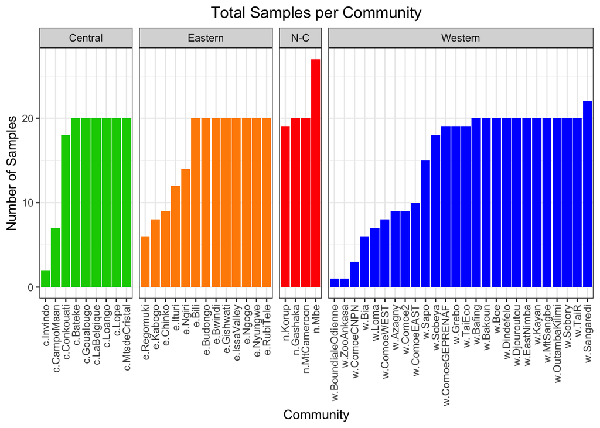

```r
plot.sample.freq(exome, title="Total Samples per Community", output.file=paste0(output_dir, "/f0/f0_samples.per.com.pdf"))
```

### Get stats for unfiltered data

```r
# Sample sizes
cat("Number of communities: ", length(unique(exome$Community)), "\n")
```

```
## Number of communities:  52
```

```r
freq.per.group=data.frame(table(exome$Community))
cat("Mean samples per community: ", mean(freq.per.group$Freq), "\n")
```

```
## Mean samples per community:  15.92308
```

```r
cat("Max samples per community: ", max(freq.per.group$Freq), "\n")
```

```
## Max samples per community:  27
```

```r
cat("Min samples per community: ", min(freq.per.group$Freq), "\n")
```

```
## Min samples per community:  1
```

```r
table(unique(exome[c('Community', 'Subspecies')])$Subspecies)
```

```
##
##          Central          Eastern Nigeria-Cameroon          Western
##                9               13                4               26
```

```r
# Coverage
cat("Median coverage: ", median(exome$Coverage), "\nMax coverage: ", max(exome$Coverage), "\nMin coverage: ", min(exome$Coverage), "\n")
```

```
## Median coverage:  1.505485
## Max coverage:  69.50464
## Min coverage:  0.0007002998
```

```r
sum(rowSums(table(unique(exome[, c("Subspecies", "Site")]))))
```

```
## [1] 52
```

```r
nrow(exome[exome$Subspecies %in% c("Central", "Eastern"),])
```

```
## [1] 356
```

### Write unfiltered BAM file list (f0)

```r
# Ensure it is ordered according to sample name
exome=exome[order(exome$Sample),]
write.table(exome$BAM.mapped.on.target, paste0(output_dir, "/bam.filelists/exome/f0_unfiltered/bam.filelist.all"),
            row.names=FALSE, col.names=FALSE, quote=FALSE)
```

Copy to myriad.

```bash
scp output/bam.filelists/f0_unfiltered/bam.filelist.all myriad:/home/ucfajos/analysis/phase1and2_exome_analysis/angsd/bam.filelists/mapped.on.target/f0_unfiltered/
```

## ANGSD

ANGSD was then run on myriad using the job script `/home/ucfajos/analysis/phase1and2_exome_analysis/angsd/scripts/mapped.on.target/run_angsd_f0.all_minInd15_doMajorMinor.1_HWE.p.1e-3_beagle.sh` (15/03/2021). Below shows the contents of this shell script.

```bash
#################################### INFO ####################################
# This script is run with doMajorMinor 1 (to ensure no excess of high freq DAFs) and a HWE filter (to ensure no bump at 0.5 due to paralogs).
# GLF is in beagle format for PCAngsd
# The output is used to plot a PCA and perform the first stage of filtering (removing PC1 outliers)
#################################### JOB ####################################
# Load modules
module load htslib
# Run ANGSD
/usr/bin/time --verbose \
~/bin/angsd/angsd \
-b /home/ucfajos/analysis/phase1and2_exome_analysis/angsd/bam.filelists/mapped.on.target/f0_unfiltered/bam.filelist.all \
-out f0.all \
-ref ~/Scratch/data/ref_genomes/hg19.fa \
-anc ~/Scratch/data/ref_genomes/homo_sapiens_ancestor_GRCh37_e71/homo_sapiens_ancestor_fullgenome.fa \
-uniqueOnly 1 \
-remove_bads 1 \
-only_proper_pairs 1 \
-trim 0 \
-C 50 \
-baq 1 \
-minInd 15 \
-skipTriallelic 1 \
-GL 2 \
-doGlf 2 \
-minMapQ 30 \
-nThreads 20 \
-doMajorMinor 1 \
-doMaf 2 \
-SNP_pval 0.000001 \
-minMaf 0.01 \
-doHWE 1 \
-minHWEpval 0.001
#################################### DONE ####################################
```

## PCAngsd

PCAngsd was then run with the job script `/home/ucfajos/analysis/phase1and2_exome_analysis/pcangsd/scripts/mapped.on.target/run_pcangsd_f0.all.sh` (15/03/2021). Below shows the contents of this shell script.

```bash
#################################### JOB ####################################
INDIR='/home/ucfajos/Scratch/output/phase1and2_exome_output/angsd_output/mapped.on.target/f0.all_minInd.15_doMajorMinor.1_HWE.p.1e-3_snp.p.1e-6_minMAF.0.01_beagle'
# Load modules
module load python3/3.7
/usr/bin/time --verbose \
python3 ~/bin/pcangsd/pcangsd.py \
-beagle ${INDIR}/f0.all.beagle.gz \
-o f0.all \
-threads 10
#################################### DONE ####################################
```

## Filtering

#### Start filter table

```r
filter.table=data.frame(t(c("f0", "Unfiltered", nrow(exome), "100%")))
colnames(filter.table)=c("Filter Name", "Filter", "Number of Samples", "% of Samples")
filter.table
```

```
##   Filter Name     Filter Number of Samples % of Samples
## 1          f0 Unfiltered               828         100%
```

### PC1 outliers

The purpose of this filter is to remove highly contaminated or non-chimp samples. Claudia ran BBsplit on chr21 outliers and found that samples may be heavily contaminated from humans or the diet of the chimps (which includes monkeys) and some samples were in fact from other large primates such as gorillas. This filter should remove such samples.

#### Plot PCA

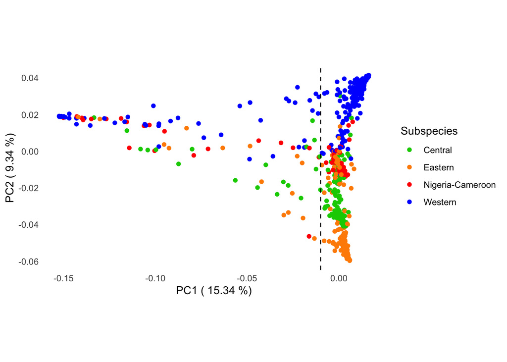

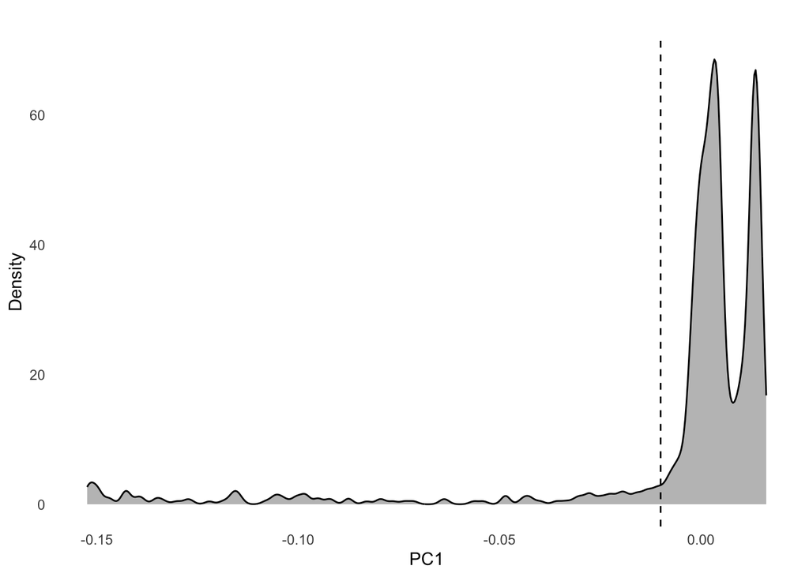

```r
# Read in PCAngsd output
cov=read.table(paste0(pcangsd_output_dir, "/f0.all_minInd.15_doMajorMinor.1_HWE.p.1e-3_snp.p.1e-6_minMAF.0.01/f0.all.cov"))
pcs=eigen(cov)
pc1.pc2=as.data.frame(pcs$vectors[,1:2])
colnames(pc1.pc2)=c("f0.PC1", "f0.PC2")
# This relies on the exome metadata file being in the same order as the BAM file input (this should be alphabetically ordered by sample name)
exome=exome[order(exome$Sample),]
pc1.pc2=cbind(exome[, c("Sample", "Site", "Subspecies")], pc1.pc2)

# Percentage variance explained by PCs
PC1.percent=pcs$values[1]/sum(pcs$values)*100
PC2.percent=pcs$values[2]/sum(pcs$values)*100
PC1.lab=paste("PC1 (", round(PC1.percent,digits = 2),"%)")
PC2.lab=paste("PC2 (", round(PC2.percent,digits = 2),"%)")

# PC1 vs PC2
f0_pc1.vs.pc2=ggplot(pc1.pc2, aes(x=f0.PC1, y=f0.PC2, fill=Subspecies, colour=Subspecies, label = Sample)) +
  theme_minimal()+
  geom_point() +
  #geom_text(size = 3) +
  labs(x=paste(PC1.lab), y=paste(PC2.lab)) +
  scale_fill_manual(values = c('green3', 'darkorange', 'red', 'blue')) +
  scale_color_manual(values = c('green3', 'darkorange', 'red', 'blue')) +
  geom_vline(xintercept = -0.01, linetype="dashed") +
  theme(panel.grid.major = element_blank(), panel.grid.minor = element_blank(),
        plot.title = element_text(hjust = 0.5)) +
  coord_equal()
ggsave(paste0(output_dir, "/f0/f0_pc1.vs.pc2.pdf"), f0_pc1.vs.pc2)
# PC1 density
f0_pc1.density=ggplot(pc1.pc2) +
  theme_minimal()+
  geom_density(aes(x=f0.PC1), col='black', fill='black',  alpha=0.3, adjust=0.5) +
  labs(title="",x ="PC1", y = "Density") +
  theme(panel.grid.major = element_blank(), panel.grid.minor = element_blank(),
        plot.title = element_text(hjust = 0.5)) +
  geom_vline(xintercept = -0.01, linetype="dashed")
ggsave(paste0(output_dir, "/f0/f0_pc1.density.pdf"), f0_pc1.density)
# Save as single figure
f0_pc1.vs.pc2_grob=ggplotGrob(f0_pc1.vs.pc2)
f0_pc1.density_grob=ggplotGrob(f0_pc1.density)
#ggsave(paste0(output_dir, "f0/f0_pc1.vs.pc2.and.pc1.density.pdf"),
#       grid.arrange(f0_pc1.density_grob, f0_pc1.vs.pc2_grob,
#                    ncol=2,
#                    widths = c(3, 4)),
#       width = 12)

for(plot in list(f0_pc1.vs.pc2, f0_pc1.density)){print(plot)}
```

Looking at the density plot I chose a threshold of -0.01 as this appears to be the point at which the density starts to rise rapidly. I therefore only keep samples with a PC1 value >-0.01.

Two peaks correspond to western and non-western samples. Both graphs look very similar to those produced using unfiltered chr21 samples.

#### PC1 filter

```r
# Add PC1 value to metadata
exome=merge(exome, pc1.pc2[,c("Sample", "f0.PC1")], by="Sample")
# Apply threshold
exome_pc1=exome[exome$f0.PC1>=(-0.01),]
```

#### Filter table

```r
filter.table=rbind(filter.table, c("", "PC1 > -0.01", nrow(exome_pc1), paste0(round(nrow(exome_pc1)/(as.numeric(filter.table[1, 'Number of Samples']))*100, digits = 2), "%")))
filter.table
```

```
##   Filter Name      Filter Number of Samples % of Samples
## 1          f0  Unfiltered               828         100%
## 2             PC1 > -0.01               721       87.08%
```

### Human contamination

We chose a 1% cutoff because that is what Claudia did.

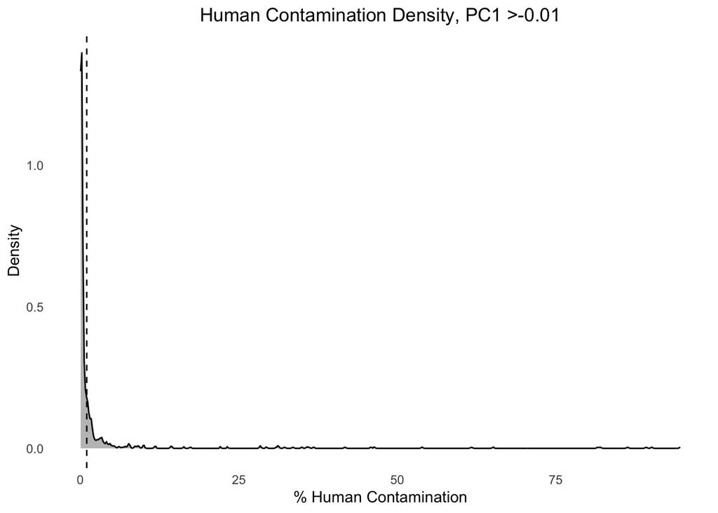

```r
# Set threshold
hc.threshold=1

# Apply threshold
exome_pc1.hc=exome_pc1[exome_pc1$`Human Contamination (%)`<=hc.threshold,]

# Plot (just to see what the data looks like, this doesn't affect out choice of threshold)
hc.plot=ggplot(exome_pc1) +
  theme_minimal()+
  geom_density(aes(x=`Human Contamination (%)`), col='black', fill='black',  alpha=0.3, adjust=0.5) +
  labs(title="Human Contamination Density, PC1 >-0.01", x ="% Human Contamination", y = "Density") +
  theme(plot.title = element_text(hjust = 0.5)) +
  geom_vline(xintercept = hc.threshold, linetype="dashed") +
  theme(panel.grid.major = element_blank(), panel.grid.minor = element_blank(),
        plot.title = element_text(hjust = 0.5))
ggsave(paste0(output_dir, "/f0/f0_hc.density.pdf"), hc.plot, width = 10, height=5)
print(hc.plot)
```

#### Filter table

```r
filter.table=rbind(filter.table, c("", "Human Cont. < 1%", nrow(exome_pc1.hc),
                                   paste0(round(nrow(exome_pc1.hc)/(as.numeric(filter.table[1, 'Number of Samples']))*100, digits = 2), "%")))
filter.table
```

```
##   Filter Name           Filter Number of Samples % of Samples
## 1          f0       Unfiltered               828         100%
## 2                  PC1 > -0.01               721       87.08%
## 3             Human Cont. < 1%               533       64.37%
```

After this filter we are left with only samples which we are confident are not contaminated.

### Coverage

We use a threshold of 0.5x as this was used for the chr21 analysis. However, the exomes are slightly lower coverage so we may end up with fewer individuals.

We may need to think about this threshold. As we are estimating allele frequencies from genotype likelihoods, having a lower mean covered threshold and more individuals per population may result in more accurate estimates of allele frequency. I have tried using no threshold and the resulting PCAs show that very low coverage sample struggle to cluster with their subspecies so for now at least we will stick to 0.5x.

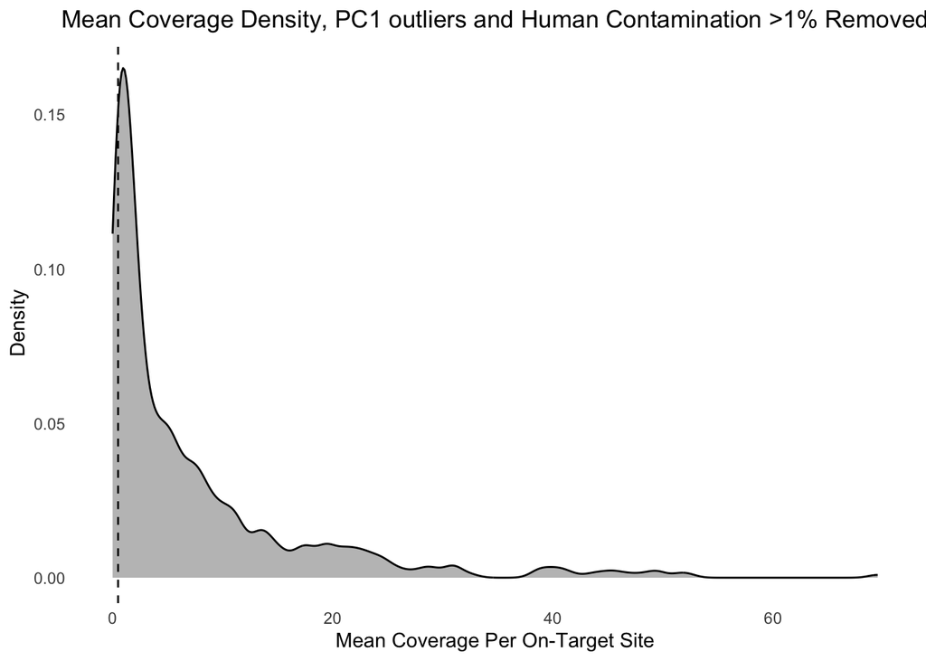

```r
# Set coverage threshold
min.cov=0.5
# Apply coverage threshold
exome_pc1.hc.c=exome_pc1.hc[exome_pc1.hc$Coverage>=min.cov,]

# Plot
cov.plot=ggplot(exome_pc1.hc) +
  theme_minimal()+
  geom_density(aes(x=Coverage), col='black', fill='black',  alpha=0.3, adjust=0.5) +
  labs(title="Mean Coverage Density, PC1 outliers and Human Contamination >1% Removed", x ="Mean Coverage Per On-Target Site", y = "Density") +
  theme(plot.title = element_text(hjust = 0.5)) +
  geom_vline(xintercept = min.cov, linetype="dashed") +
  theme(panel.grid.major = element_blank(), panel.grid.minor = element_blank(),
        plot.title = element_text(hjust = 0.5))
ggsave(paste0(output_dir, "/f0/f0_hc.density.pdf"), cov.plot, width = 10, height=5)
print(cov.plot)
```

```r
head(exome_pc1.hc[order(-exome_pc1.hc$Coverage),])
```

```
##        Sample Sample Type       Site     Country       Subspecies      hDNA
## 594    Mbe1-7       Feces        Mbe     Nigeria Nigeria-Cameroon 13.983027
## 630   N260-10       Feces      Ngogo      Uganda          Eastern 14.520000
## 186  CNPN1-20       Feces Comoe-CNPN Ivory Coast          Western 15.816391
## 155 Chinko-14       Feces     Chinko         CAR          Eastern  5.665084
## 628    N259-6       Feces      Ngogo      Uganda          Eastern 38.690000
## 212   Con2-80       Feces  Conkouati       Congo          Central 40.860000
##     Average Fragment Size GQN (Fragmentation Score) Longitude   Latitude
## 594                  1063                       1.6  9.079528  6.2450417
## 630                  3021        4.9000000000000004 30.450716  0.4859825
## 186                  1659                       3.8 -3.914734  8.9647300
## 155                  2669                       6.7 24.305405  6.1546300
## 628                  4006                       5.3 30.450716  0.4859825
## 212                  6729                       7.2 11.199129 -3.9472617
##     Method for hDNA quantification Coverage Human Contamination (%)
```

[output cut: 34 more lines]

NB: This distribution looks similar to that for chr21, if anything, the exomes look less exponential with more samples with high coverage. Chr21 also had some samples with very high coverage (>50x).

#### What are these very high coverage samples?

Here I pull out the statistics for the unusually high coverage samples to make sure it all looks ok. chr21 also had some high coverage samples.

```r
head(exome_pc1.hc.c[order(-exome_pc1.hc.c$Coverage), c("Sample", "Community", "Coverage", "Human Contamination (%)", "hDNA", "Average Fragment Size", "Method for hDNA quantification", "Num Position  (Human Contamination)")], 10)
```

```
##        Sample      Community Coverage Human Contamination (%)      hDNA
## 594    Mbe1-7          n.Mbe 69.50464                   0.184 13.983027
## 630   N260-10        e.Ngogo 52.27317                   0.105 14.520000
## 186  CNPN1-20    w.ComoeCNPN 51.42639                   0.091 15.816391
## 155 Chinko-14       e.Chinko 49.50320                   0.176  5.665084
## 628    N259-6        e.Ngogo 49.49093                   0.081 38.690000
## 212   Con2-80    c.Conkouati 48.29989                   0.103 40.860000
## 629    N259-8        e.Ngogo 47.00230                   0.063  5.249227
## 625    N186-9        e.Ngogo 45.82381                   0.071  5.638668
## 170   Cnp1-36       w.Comoe2 45.29059                   0.090  8.341608
## 602   Mtc1-58 c.MtsdeCristal 44.39632                   0.101  5.368427
##     Average Fragment Size Method for hDNA quantification
## 594                  1063                        Shotgun
## 630                  3021                        Shotgun
## 186                  1659                        Shotgun
```

[output cut: 18 more lines]

I can’t see any red flags such as high human contamination.

#### Filter table

```r
filter.table=rbind(filter.table, c("f1", paste0("Coverage > ", min.cov, "x"), nrow(exome_pc1.hc.c), paste0(round(nrow(exome_pc1.hc.c)/(as.numeric(filter.table[1, 'Number of Samples']))*100, digits = 2), "%")))
write.csv(filter.table, paste0(output_dir, "/f1/f1.filtertable.csv"), row.names=F)
filter.table
```

```
##   Filter Name           Filter Number of Samples % of Samples
## 1          f0       Unfiltered               828         100%
## 2                  PC1 > -0.01               721       87.08%
## 3             Human Cont. < 1%               533       64.37%
## 4          f1  Coverage > 0.5x               467        56.4%
```

#### Coverage of remaining samples

```r
mean(exome_pc1.hc.c$Coverage)
```

```
## [1] 8.483566
```

```r
median(exome_pc1.hc.c$Coverage)
```

```
## [1] 4.703454
```

### Chr21 Outliers

These samples were identified by Claudia and emailed to me 08/03/2021. They were excluded from the chr21 analysis as they were PC1 outliers and are likely contaminated. The list is 100 samples long which is a suspiciously round number but I have confirmed with Claudia it is not truncated.

```r
chr21.pca.outliers=c('Baf2-42','Bat1-3','Bat1-6','Bil1-10','Bil1-20','Bud2-29','Bwi1-55','Bwi1-90','Bwi-2-39','Cam1-18','Cam1-21','Cam1-26','Cam1-44','Cam1-49','Cam1-50','Cam1-71','Cam1-74','Cam1-78','Cam2-77','Cam3-40','Cam3-41','CMNP1-19','CMNP1-43','CNPE1-12','CNPE1-1','CNPE1-26','CNPE1-2','CNPE1-31','CNPE1-36','CNPE1-3','Con2-67','Con2-71','Con3-8','Din1-68','Dja1-17','Dja3-6','Dja3-7','Djo1-50','Fjn1-10','Fjn3-56','Gas2-67','GB-29-06','GB-30-11','GB-37-09','Gbo1-53','Gep1-23','Gep1-65','Gha-01-01','Gou1-40','Itu-01-06','Itu-01-09','Itu-01-10','Itu-01-11','Kab2-1','Kay2-52','Kor2-17','Kor2-1','Kor2-26','Kor2-35','Kor2-5','Lib1-6-D','Loma2-1','Loma2-2','Loma2-7','Mbe-02-04','Mbe-02-05','Mbe-02-07','Mbe-02-09','Mbe-02-12','Mbe-02-13','Mbe1-21','Mbe1-2','Mbe1-9','Mtc1-43','MTC2-40','N173-17','Onp1-26','Onp1-32','Onp1-34','Onp1-35','Rt2-41','Sob1-32','Sob1-47','Tai-E1-42','Tai-E1-50','Tai-E1-52','Tai-E1-54','Tai-E1-55','Tai-E1-56','Tai-E1-58','Tai-E1-60','Tai-E1-7','Tai-E2-18','Tai-E2-48','Tai-E2-51','Tai_R1-23','Tai_R1-26','Tai_R2-16','Tai_R2-22','Tai_R2-9')
```

```r
nrow(exome_pc1.hc.c[!(exome_pc1.hc.c$Sample %in% chr21.pca.outliers),])
```

```
## [1] 467
```

We can see that all the samples identified as PC1 outliers by Claudia are also removed using my filters increasing my confidence that we have removed the worst samples.

```r
# How many chr21 PC1 outliers are there?
length(chr21.pca.outliers)
```

```
## [1] 100
```

```r
# How chr21 PC1 outliers are also exome PC1 outliers?
nrow(exome[exome$f0.PC1<(-0.01) & (exome$Sample %in% chr21.pca.outliers),])
```

```
## [1] 94
```

```r
# How many chr21 PC1 outliers are identified as having >1% human contamination?
nrow(exome[exome$`Human Contamination (%)`>1 & (exome$Sample %in% chr21.pca.outliers),])
```

```
## [1] 100
```

```r
# How many chr21 PC1 outliers have too low coverage?
nrow(exome[exome$Coverage<=min.cov & (exome$Sample %in% chr21.pca.outliers),])
```

```
## [1] 51
```

Of the outliers identified with chr21, 94% are also outliers in the exome analysis, 100% are identified as having >1% human contamination and 51% have too low coverage (for 0.5x threshold).

```r
sum(head(exome[order(exome$f0.PC1),],100)$Sample %in% chr21.pca.outliers)
```

```
## [1] 91
```

```r
exome[exome$f0.PC1<(-0.01) & !(exome$Sample %in% chr21.pca.outliers),]
```

```
##        Sample Sample Type        Site     Country Subspecies       hDNA
## 1   AZA-01-01        Hair      Azagny Ivory Coast    Western 0.25633920
## 35    Bat1-16       Feces      Bateke       Gabon    Central 0.03035849
## 200   Con2-27       Feces   Conkouati       Congo    Central 0.03601144
## 209   Con2-66       Feces   Conkouati       Congo    Central 0.12550607
## 261    Djo1-5       Feces  Djouroutou Ivory Coast    Western 0.64809080
## 354  GB-36-16       Feces      Loango       Gabon    Central 0.04781675
## 421 Gha-01-07       Feces         Bia       Ghana    Western 0.05208847
## 486   Kay1-12       Feces       Kayan     Senegal    Western 0.82000000
## 527  Lib1-25D       Feces        Sapo     Liberia    Western 0.58000000
## 683   NNP2-54       Feces     Nyungwe      Rwanda    Eastern 0.70634070
## 686   NNP2-68       Feces     Nyungwe      Rwanda    Eastern 0.06321298
## 785  Tai_R2-6       Feces     Tai_Eco Ivory Coast    Western 0.26698258
## 822   Uga2-46       Feces Issa Valley    Tanzania    Eastern 0.03347543
##     Average Fragment Size GQN (Fragmentation Score)  Longitude  Latitude
```

[output cut: 83 more lines]

### Write BAM file lists

This BAM file list can be used for input into ngsRelate (analysed in the next script, f2_exome.sample.filtering.Rmd). The related individuals and outliers can then be identified and the final stage of filtering can be done.

#### All

```r
# Ensure it is ordered according to sample name
exome_pc1.hc.c=exome_pc1.hc.c[order(exome_pc1.hc.c$Sample),]
# All
write.table(exome_pc1.hc.c$BAM.mapped.on.target, paste0(output_dir, "/bam.filelists/exome/f1_pc1_hc.1pct_coverage.", min.cov, "x/bam.filelist.all"),
            row.names=FALSE, col.names=FALSE, quote=FALSE)
```

#### Subspecies

```r
# Central
write.table(exome_pc1.hc.c[exome_pc1.hc.c$Subspecies=="Central",]$BAM.mapped.on.target,
            paste0(output_dir, "/bam.filelists/exome/f1_pc1_hc.1pct_coverage.", min.cov, "x/bam.filelist.c"),
            row.names=FALSE, col.names=FALSE, quote=FALSE)
# Eastern
write.table(exome_pc1.hc.c[exome_pc1.hc.c$Subspecies=="Eastern",]$BAM.mapped.on.target,
            paste0(output_dir, "/bam.filelists/exome/f1_pc1_hc.1pct_coverage.", min.cov, "x/bam.filelist.e"),
            row.names=FALSE, col.names=FALSE, quote=FALSE)
# Nigeria-Cameroon
write.table(exome_pc1.hc.c[exome_pc1.hc.c$Subspecies=="Nigeria-Cameroon",]$BAM.mapped.on.target,
            paste0(output_dir, "/bam.filelists/exome/f1_pc1_hc.1pct_coverage.", min.cov, "x/bam.filelist.n"),
            row.names=FALSE, col.names=FALSE, quote=FALSE)
# Western
write.table(exome_pc1.hc.c[exome_pc1.hc.c$Subspecies=="Western",]$BAM.mapped.on.target,
            paste0(output_dir, "/bam.filelists/exome/f1_pc1_hc.1pct_coverage.", min.cov, "x/bam.filelist.w"),
            row.names=FALSE, col.names=FALSE, quote=FALSE)
```

#### Communities

I am writing communities (rather than populations) because I think we shouldn’t combine them until doing actual population genetic tests as we only lose information and resolution and it isn’t necessary. Before then, while we are still filtering the samples and looking at demography it is important to keep them separate.

We need to run ngsRelate per community (population structure messes up the analysis according to Claudia).

```r
coms=unique(exome_pc1.hc.c$Community)
for(com in coms){
  exome_pc1.hc.c.com=exome_pc1.hc.c[exome_pc1.hc.c$Community==com, ]
  write.table(exome_pc1.hc.c.com$BAM.mapped.on.target, paste0(output_dir, "/bam.filelists/exome/f1_pc1_hc.1pct_coverage.", min.cov, "x/bam.filelist.", com),
            row.names=FALSE, col.names=FALSE, quote=FALSE)
}
```

##### Write list of communities to loop over

This writes the lists of communities as a text file so they can just be copied and pasted into the angsd script so it loops over them like so…

`for POP in c.Bateke c.CampoMaan c.Conkouati...` (this is where you paste the list of communities)

`do`

`angsd ...`

`done`

Notice I have used the communities column from the unfiltered file, this is just so that I definitely loop over all possible communities (if I change the filters at any point and that changes the communities in the filtered file this wont make a difference).

```r
com.list=t(unique(exome[order(exome$Community),]$Community))
write.table(com.list, paste0(output_dir, "/com.list.txt"),
            row.names=FALSE, col.names=FALSE, quote=FALSE)
```

```bash
scp -r output/bam.filelists/mapped.on.target/f1_pc1_hc.1pct_coverage.*x/ myriad:/home/ucfajos/analysis/phase1and2_exome_analysis/angsd/bam.filelists/mapped.on.target/
```

ANGSD is then run to produce genotype likelihood files (beagle format for PCAngsd, .glf.gz for ngsRelate) and an allele frequency file (for ngsRelate) to run PCAngsd and ngsRelate.

## Write metadata

```r
write.table(exome_pc1.hc.c, paste0(output_dir, "/f1/f1.metadata.csv"), sep=",", row.names=FALSE, col.names=TRUE, quote=FALSE)
```

# NEXT- f2_exome.sample.filtering.Rmd

f2_exome.sample.filtering.Rmd analyses ngsRelate output to remove related individuals.